# Section 1: Unsupervised Analysis

William Figgett and Leonard Goldstein

Garvan Institute of Medical Research

23 August 2023

This workshop is mainly adapted from the mixOmics tutorials (http://mixomics.org) and the Bioconductor vignette (https://bioconductor.org/packages/release/bioc/html/mixOmics.html).

# 1 Load dataset

We will start by loading the mixOmics package, which includes most of the method functions and example data for this workshop.

The example dataset has 3 dataframes of measurements (miRNA, mRNA, protein) from three experiment groups (three human cancer cell subtypes).

By convention for the mixOmics methods, data is arranged with samples as rows (and the same order of samples in all data frames) and feature measurements as columns.

```r
library(mixOmics)
data(breast.TCGA)

# Extract training data and name each data frame
# There are 3 dataframes (3 omics of the same samples), stored as list
# In each dataframe, the rows represent samples.
# Columns represent feature measurments (genes, miRNA, protein)
X <- list(miRNA = breast.TCGA$data.train$mirna,
          mRNA = breast.TCGA$data.train$mrna,
          protein = breast.TCGA$data.train$protein)
```

Examine the structure of “X”

```r
str(X)
```

```
## List of 3
##  $ miRNA  : num [1:150, 1:184] 11.8 12.9 12.3 12 13.4 ...
##   ..- attr(*, "dimnames")=List of 2
##   .. ..$ : chr [1:150] "A0FJ" "A13E" "A0G0" "A0SX" ...
##   .. ..$ : chr [1:184] "hsa-let-7a-1" "hsa-let-7a-2" "hsa-let-7a-3" "hsa-let-7b" ...
##  $ mRNA   : num [1:150, 1:200] 4.36 1.98 1.73 4.36 2.45 ...
##   ..- attr(*, "dimnames")=List of 2
##   .. ..$ : chr [1:150] "A0FJ" "A13E" "A0G0" "A0SX" ...
##   .. ..$ : chr [1:200] "RTN2" "NDRG2" "CCDC113" "FAM63A" ...
##  $ protein: num [1:150, 1:142] 0.0491 -0.08 -0.0328 -0.2053 0.0602 ...
##   ..- attr(*, "dimnames")=List of 2
##   .. ..$ : chr [1:150] "A0FJ" "A13E" "A0G0" "A0SX" ...
##   .. ..$ : chr [1:142] "14-3-3_epsilon" "4E-BP1" "4E-BP1_pS65" "4E-BP1_pT37" ...
```

View the first 3 rows and columns of data for each datatype. The data are arranged with samples as rows, and ‘features’ (e.g. genes) as columns.

```r
X$miRNA[1:3,1:3]
```

```
##      hsa-let-7a-1 hsa-let-7a-2 hsa-let-7a-3
## A0FJ     11.83582     12.85105     11.91881
## A13E     12.89793     13.90087     12.91273
## A0G0     12.30773     13.29032     12.30062
```

```r
X$mRNA[1:3,1:3]
```

```
##          RTN2    NDRG2  CCDC113
## A0FJ 4.362183 7.533461 3.956124
## A13E 1.984492 7.455194 5.427623
## A0G0 1.727323 8.079968 2.227300
```

```r
X$protein[1:3,1:3]
```

```
##      14-3-3_epsilon    4E-BP1 4E-BP1_pS65
## A0FJ     0.04913078 0.4474862 -0.07432175
## A13E    -0.07998211 0.6052184  0.28891184
## A0G0    -0.03284989 0.8946097  0.89127784
```

```r
# check the minimum value in each block
lapply(X, FUN = min)
```

```
## $miRNA
## [1] 0.02478406
##
## $mRNA
## [1] 0.007846794
##
## $protein
## [1] -5.985793
```

```r
# check the amount of NA values in each block
lapply(X, FUN = function(w) sum(is.na(w)))
```

```
## $miRNA
## [1] 0
##
## $mRNA
## [1] 0
##
## $protein
## [1] 0
```

- Missing values are not desirable but may be necessary in some types of data (e.g. 16S).
- This example data has no NA values (good).
- Protein data includes negative values.

Check that the samples (row names) are exactly the same across each ’omics layer.

```r
identical(row.names(X$mRNA), row.names(X$miRNA))
```

```
## [1] TRUE
```

```r
identical(row.names(X$mRNA), row.names(X$protein))
```

```
## [1] TRUE
```

Get and summarise experiment groups (in this example, the subtype of cancer cell).

```r
Y <- breast.TCGA$data.train$subtype

# summary statistics
summary(Y)
```

```
## Basal  Her2  LumA
##    45    30    75
```

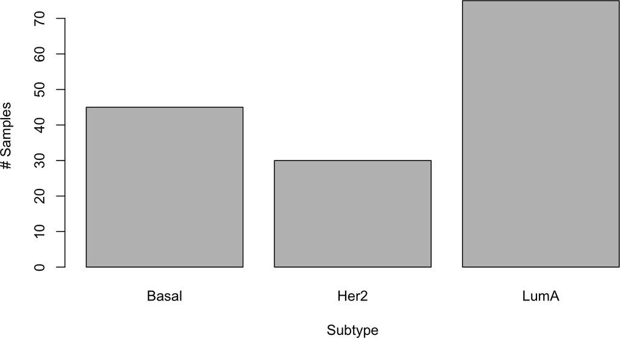

```r
barplot(summary(Y), ylab = "# Samples", xlab = "Subtype")
```

# 2 Data preparation

mixOmics methods assume the input data are already ‘cleaned’ and prepared appropriately for each type of measurement. For example, lowly or non-expressed genes may need to be removed from consideration. ‘NA’ or 0 values might be expected in some datasets but not others.

RNA-seq count data typically needs normalisation for library depth. Note that data preparation might need to be handled differently for some data layers; in this example data we will apply upper-quartile normalisation to RNA/miRNA samples.

We can inspect the data distributions per sample, on a bloxplot of log2-transformed data.

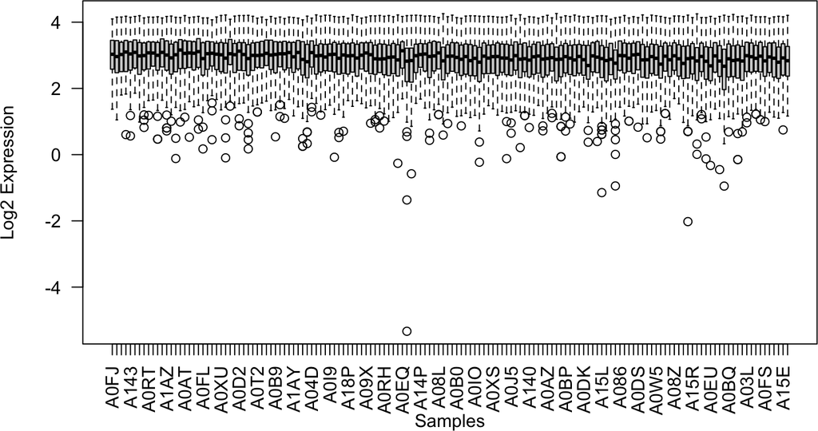

```r
# plot miRNA and mRNA data with log2 transformation
boxplot(log2( t(X$miRNA)) , xlab="Samples", ylab="Log2 Expression", las=2)
```

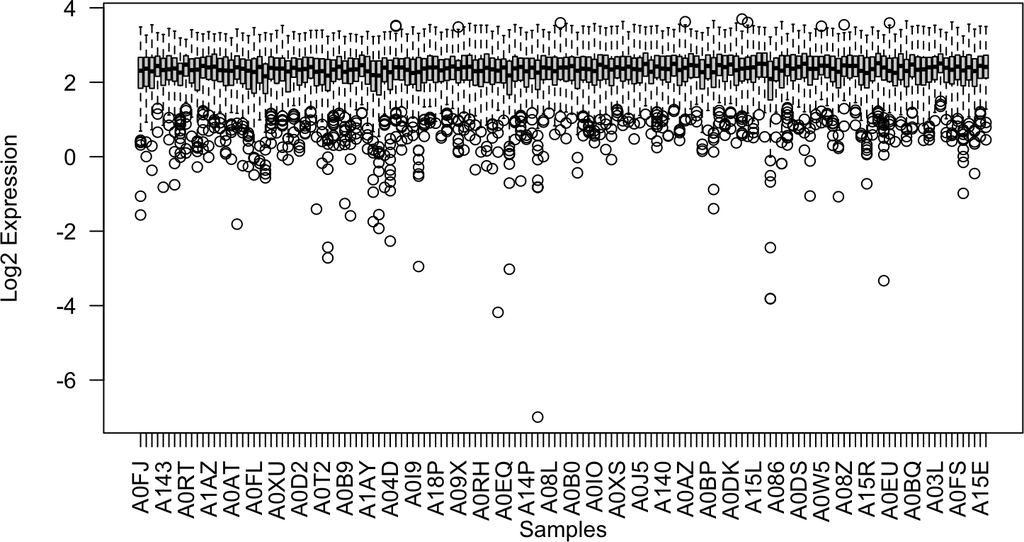

```r
boxplot(log2( t(X$mRNA)) , xlab="Samples", ylab="Log2 Expression", las=2)
```

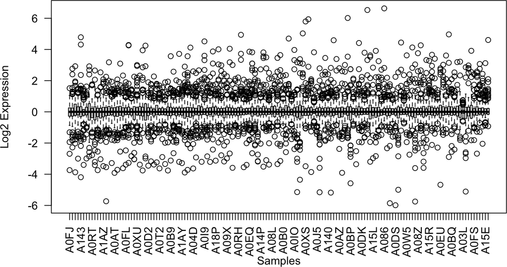

```r
# plot protein data without log2, since it includes negative values
boxplot(t(X$protein) , xlab="Samples", ylab="Log2 Expression", las=2)
```

- Example miRNA and mRNA data appear to be already reasonably close for library depth and log-transformed/scaled.
- Example protein data appears already median-normalised, centred and autoscaled.
- All of these example data are prepared suitably for mixOmics methods, but we can try adding normalisation to these data for practice.
- Note for mRNA and miRNA data (and other count-based omics, e.g. 16S and shotgun metagenomics), the methods work with count based data frames - provided that unwanted features are removed and counts are adjusted for library depth. Adding an offset +1 to count based data frames containing zero values is also recommended.

## 2.1 Normalisation function

Lets make a function, which could be reused on multiple datasets (with the default processing being upper-quartile normalisation, or switch to median normalisation for protein data later).

```r
normaliseSampleData <- function(data, q="75%", centerMedians=FALSE) {
  # apply normalisation to data with: normaliseSampleData(data)
  #       by default q="75%" for upper-quartiles.
  # apply median normalisation to data with: normaliseSampleData(data, q="50%")
  # add median centering with: normaliseSampleData(data, q="50%", centerMedians=TRUE)

  scalefactor <- vector()
  for (i in 1:nrow(data)) {
    scalefactor[i] <- quantile(data[i,])[q]
  }

  # divide by scalefactor and multiply by the median
  normalised.data <- data
  for (i in 1:nrow(data)) {
    normalised.data[i,] <- normalised.data[i,] / scalefactor[i] * mean(scalefactor)
  }

  if (centerMedians) {
    sampleMedians <- apply(normalised.data, MARGIN = 1, FUN = median)
    for (i in 1:nrow(data)) {
      normalised.data[i,] <- normalised.data[i,] - sampleMedians[i]
    }
  }
  # give back the normalised data result
  return(normalised.data)
}
```

## 2.2 Normalising data

Let’s apply the function to mRNA data, and compare the raw vs normalised data. For illustration, the raw data will be arbitrarily modified to simulate unequal library depths.

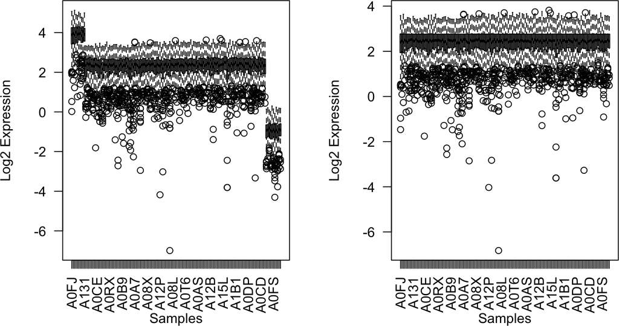

```r
# make the first 10 samples have triple depth.
X$mRNA[1:10,] <- X$mRNA[1:10,] * 3

# make the last 10 samples have 10% depth.
X$mRNA[140:150,] <- X$mRNA[140:150,] / 10

X$mRNA.uq <- normaliseSampleData(data = X$mRNA)

par(mfrow=c(1,2))
boxplot(log2( t(X$mRNA)) , xlab="Samples", ylab="Log2 Expression", las=2)
boxplot(log2( t(X$mRNA.uq)) , xlab="Samples", ylab="Log2 Expression", las=2)
```

- Let’s apply the normalisation function to miRNA, again normalising by upper quartile.
- The protein data is a bit different, median normalisation is typically recommended.

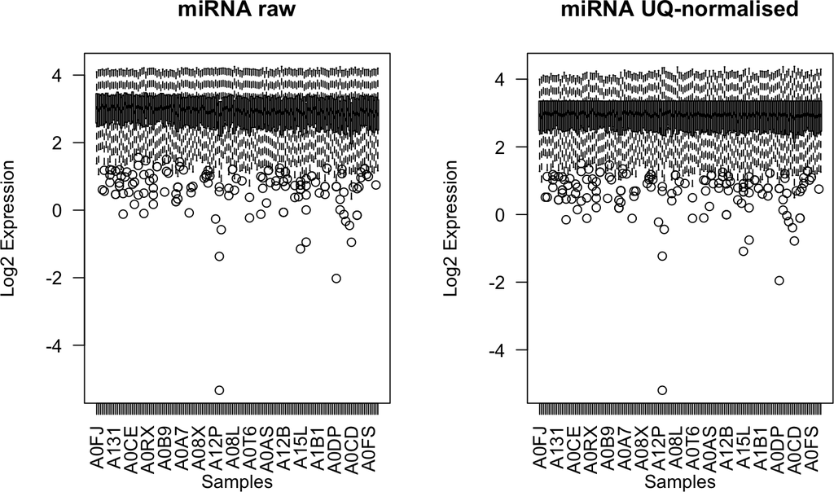

```r
# normalise by upper quartile
X$miRNA.uq <- normaliseSampleData(data = X$miRNA)
par(mfrow=c(1,2))
boxplot(log2(t(X$miRNA)) , xlab="Samples", ylab="Log2 Expression", las=2, main="miRNA raw")
boxplot(log2(t(X$miRNA.uq)) , xlab="Samples", ylab="Log2 Expression", las=2,  main="miRNA UQ-normalised")
```

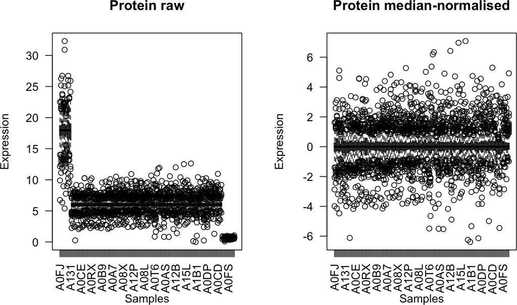

```r
# add an offset to the protein data to remove it from negative values
X$protein <- X$protein - min(X$protein)

# simulate unequal sample loadings again in Protein data
X$protein[1:10,] <- X$protein[1:10,] * 3
X$protein[140:150,] <- X$protein[140:150,] / 10

# apply median normalisation and centering on protein data
X$protein.norm <- normaliseSampleData(data = X$protein, q="50%", centerMedians = TRUE)

par(mfrow=c(1,2))
boxplot(t(X$protein), xlab="Samples", ylab="Expression", las=2, main="Protein raw")
boxplot(t(X$protein.norm), xlab="Samples", ylab="Expression", las=2, main="Protein median-normalised")
```

# 3 PCA

Principle Component Analysis (PCA) is a dimension-reduction technique, useful for exploration of high-dimensional data. The overall variance between samples can be approximately visualised, by plotting samples by their leading Principal Components (PC1 vs PC2).

## 3.1 pca()

The *pca()* function takes a matrix of values (sample-rows by feature-columns), and a calculates a chosen number of principle components. The option to transform data by autoscale (scale = TRUE) is the default.  
Optionally, it may be advantageous to add the center-log-ratio transformation (logratio = “CLR”) for proportion data, e.g. for 16S sequencing data (microbial abundance counts) or RNAseq read counts. The count/proportion data becomes “continuous” for the purposes of multivariate exploration.

Plotting the *pca* object with *plot()* displays a bar graph of the components, which are in descending order of the % of variance in the dataset that they represent. The idea is to pack most of the variance onto the leading components and plot those as a rough approximation of total dataset variance.

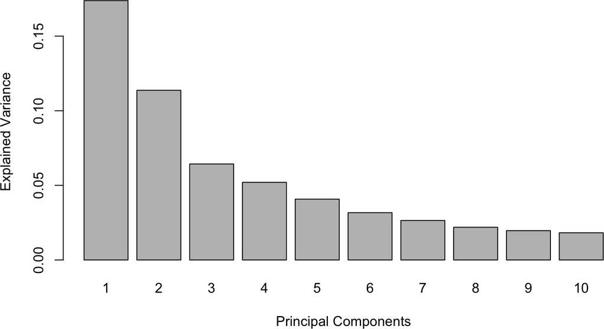

```r
# Use the *pca* function on the mRNA data, applying scaling and CLR transformation.
pca.mRNA <- pca(X$mRNA.uq, ncomp=10, center = TRUE, scale = TRUE, logratio = "CLR")

# plot the components in order of explained variance (%).
plot(pca.mRNA)
```

```r
# access the explained variance (%) values
pca.mRNA$prop_expl_var$X
```

```
##        PC1        PC2        PC3        PC4        PC5        PC6        PC7
## 0.17377838 0.11368167 0.06434452 0.05202143 0.04076636 0.03171319 0.02647689
##        PC8        PC9       PC10
## 0.02192884 0.01964795 0.01822668
```

## 3.2 Sample plot

The main mixOmics function to plot samples is *plotIndiv()*.

When applied to a pca object, the x and y axes default to components 1 and 2, respectively.

*ind.names = TRUE* by default, which will add the sample labels to the points, although usually setting this to FALSE and adding the group information and ellipses is useful to highlight group differences/overlap.

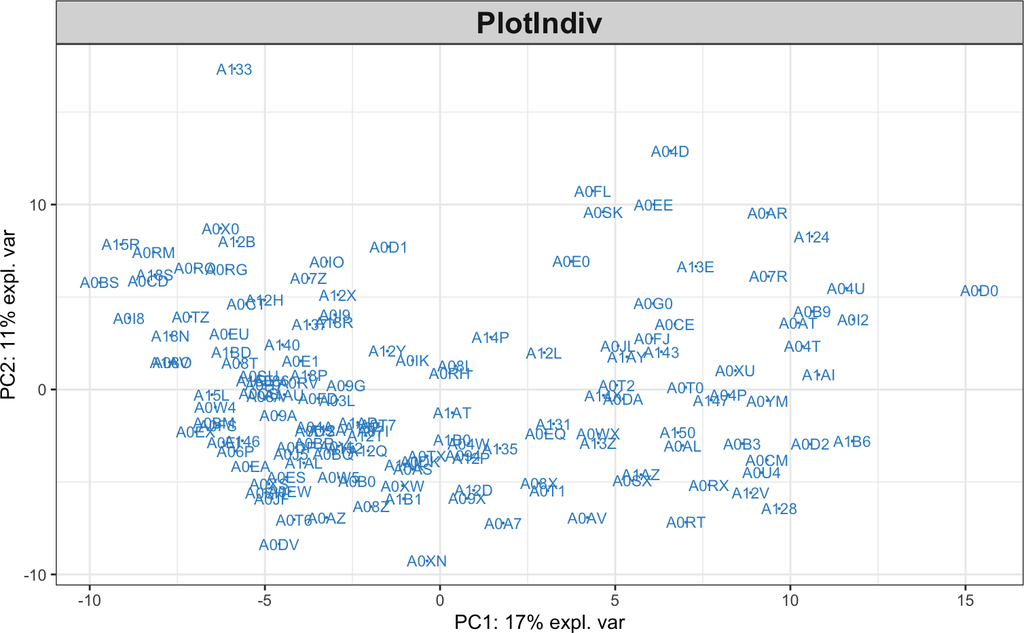

```r
# the plot of samples, with default settings
plotIndiv(pca.mRNA)
```

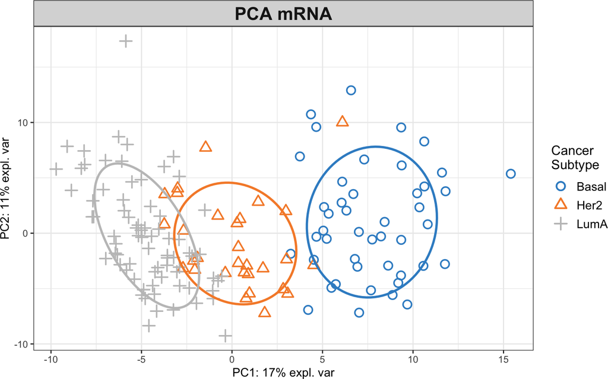

```r
# the plot of samples, with settings adjusted to show experimental groups and
# add ellipses representing a confidence interval of 0.6.
plotIndiv(pca.mRNA, ind.names = FALSE, group = Y, ellipse = TRUE,
          ellipse.level = 0.6, legend = TRUE,
          legend.title = "Cancer\nSubtype", title = "PCA mRNA")
```

## 3.3 Loadings

Inspect the loadings of the main two components with plotLoadings(), choosing to show the top-10 features by weight.

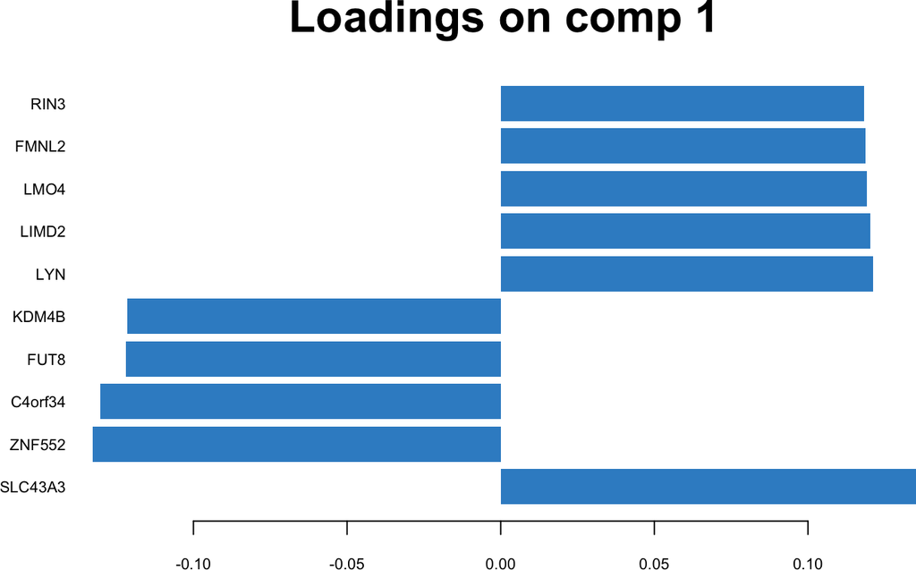

```r
plotLoadings(pca.mRNA, comp = 1, ndisplay = 10)
```

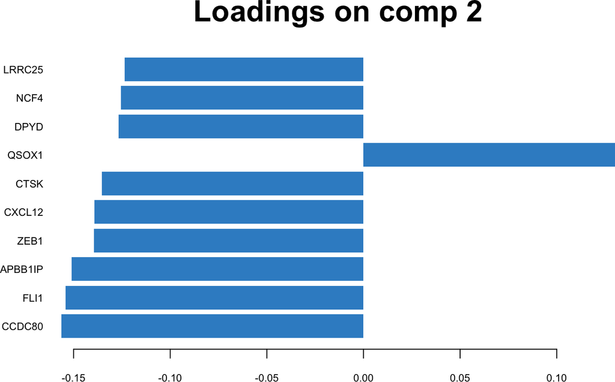

```r
plotLoadings(pca.mRNA, comp = 2, ndisplay = 10)
```

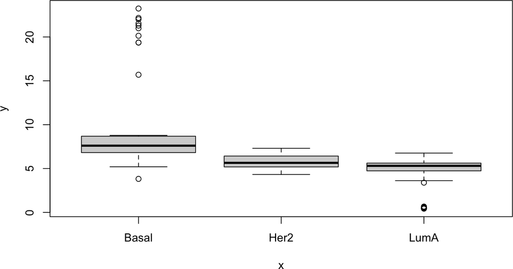

```r
# view expression of the top-weighted gene, per experiment group
plot(x=factor(Y), y = X$mRNA[,"SLC43A3"])
```

## 3.4 Practice

- Run PCA and inspect the loadings for the other data layers (miRNA, and protein).

```r
# Use the *pca* function the other two data layers

# pca.miRNA <- pca(X$miRNA.uq, ...

# plotIndiv(pca.miRNA, ...

# plotLoadings(pca.miRNA ...
```

## 3.5 PCA on a subset of data

- Subset to the high variance genes, and run *pca()*

```r
gene.varances <- apply(X$mRNA.uq, MARGIN = 2, FUN = var)

# get the top 50 genes by variance
top.variance.genes <- names(gene.varances[order(gene.varances, decreasing = TRUE)][1:50])
top.variance.genes
```

```
##  [1] "STC2"      "APOD"      "NTN4"      "MEX3A"     "ALCAM"     "FLJ23867"
##  [7] "SEMA3C"    "TTC39A"    "PREX1"     "GPC4"      "EGLN3"     "CSF3R"
## [13] "LMO4"      "POSTN"     "ZNF552"    "RUNX3"     "IFIT3"     "MT1X"
## [19] "ASPM"      "NDRG2"     "EPHB3"     "SEMA5A"    "RGS1"      "CSRP2"
## [25] "AKAP12"    "BOC"       "CCNA2"     "E2F1"      "LIMD2"     "HIST1H2BK"
## [31] "LAPTM4B"   "CDK18"     "SAMD9L"    "RHOU"      "SDC1"      "CBR1"
## [37] "CXCL12"    "CCDC80"    "PLEKHA4"   "NCOA7"     "KIF13B"    "S100A16"
## [43] "CTSK"      "TANC2"     "HLA-H"     "PLCD4"     "SNED1"     "WWC2"
## [49] "ITPR2"     "SLC43A3"
```

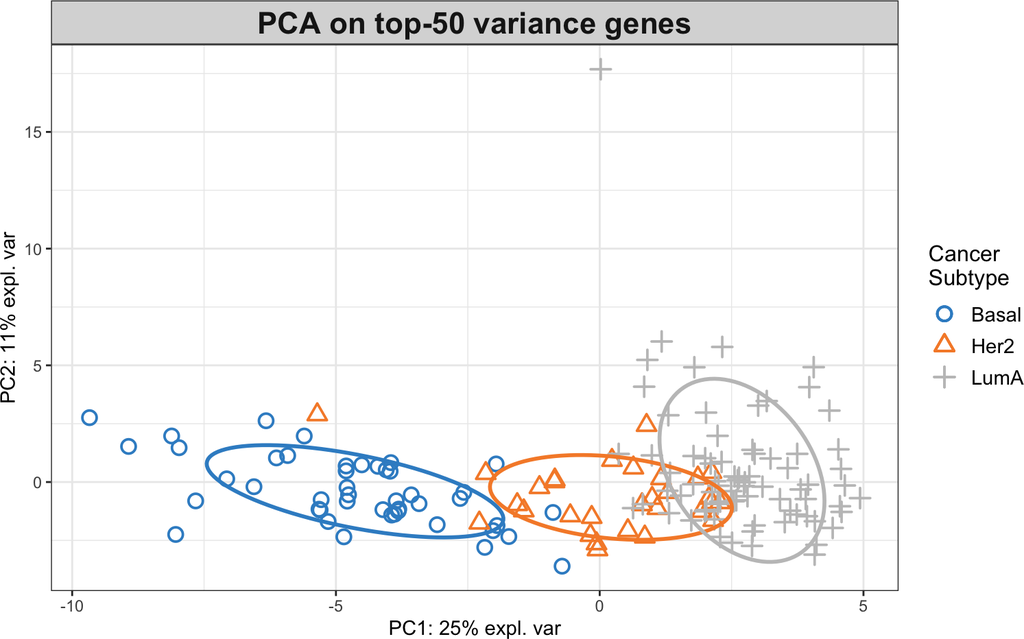

```r
pca.mRNA.variance <- pca(X$mRNA[,top.variance.genes], ncomp = 10, center = TRUE,
                         scale = TRUE, logratio = "CLR")
plotIndiv(pca.mRNA.variance, ind.names = FALSE, group = Y, ellipse = TRUE,
          ellipse.level = 0.6, legend = TRUE,
          legend.title = "Cancer\nSubtype", title = "PCA on top-50 variance genes")
```

- In this plot, component 2 becomes much less helpful - it seems to be driven by an outlier sample.

# 4 UMAP

PCA and Uniform Manifold Approximation and Projection (UMAP) are both dimensionality reduction techniques that can be used to reduce the number of features in a dataset while preserving the underlying structure of the data.

PCA is usually effective as a first step at finding the overall directions of variation in the data, but it can be less effective at preserving local structure than UMAP, which is typically more balanced in preserving both global and local structure. UMAP provides an alternate visualisation of clusters and other patterns in the data.

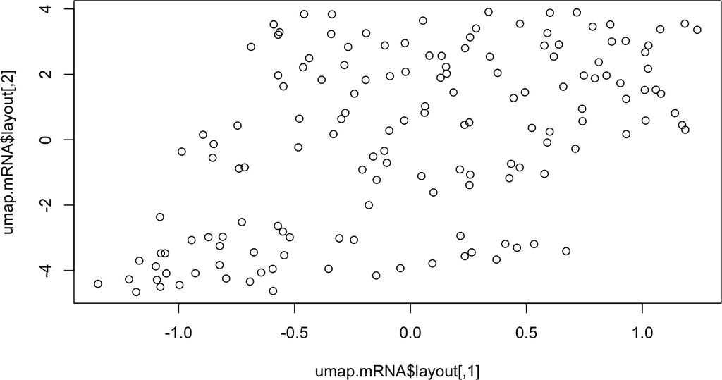

```r
library(umap)

umap.mRNA <- umap(X$mRNA.uq)

plot(umap.mRNA$layout)
```

# 5 ggplot graphics

- Coordinate values can be extracted from pca and umap objects, for making custom ggplot graphics.
- ggplot gives you a *lot* of control over the graphical elements, and there are many packages that extend its capabilities.
- Note that in earlier versions of mixOmics the location of these values may be found a bit deeper in the model object, for example, in the current version (6.24.0) the coordinates from pca are found in **pca.mRNA$x**, but for earlier versions you might need to access them from **pca.mRNA$loadings$X**.

```r
library(ggplot2) # this line is not strictly necessary in this session since
# ggplot2 was loaded already from mixOmics.

str(pca.mRNA$x)
```

```
##  num [1:150, 1:10] 6.06 7.3 6.09 5.49 6.32 ...
##  - attr(*, "dimnames")=List of 2
##   ..$ : chr [1:150] "A0FJ" "A13E" "A0G0" "A0SX" ...
##   ..$ : chr [1:10] "PC1" "PC2" "PC3" "PC4" ...
```

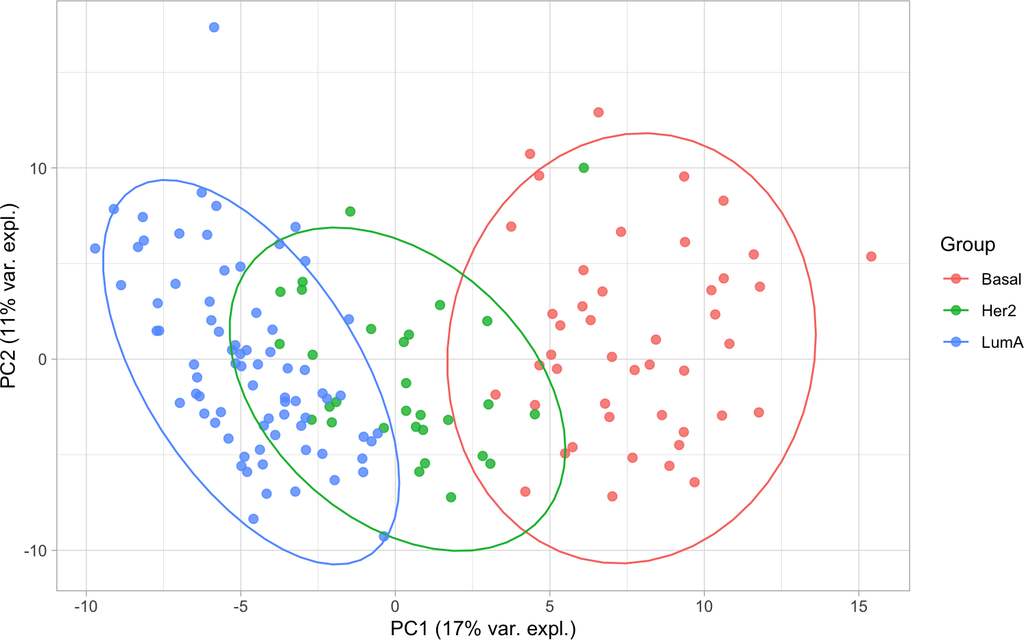

```r
ggplot(data = data.frame(Group = Y, pca.mRNA$x),
       aes(colour=Group, x=PC1, y=PC2)) +
         geom_point(size=2, alpha=0.8) + theme_light() +
  xlab(paste0("PC1 (", round(pca.mRNA$prop_expl_var$X[1]*100), "% var. expl.)")) +
  ylab(paste0("PC2 (", round(pca.mRNA$prop_expl_var$X[2]*100), "% var. expl.)")) +
  stat_ellipse()
```

```r
# ggsave() is useful for saving figures with a specific size and resolution.
# It saves that ggplot that was most recently generated.
ggsave(filename="mRNA.PCA.png", units = "cm", width=12, height=8, dpi = 320)

str(umap.mRNA$layout)
```

```
##  num [1:150, 1:2] -0.795 -1.17 -1.098 0.264 -0.823 ...
##  - attr(*, "dimnames")=List of 2
##   ..$ : chr [1:150] "A0FJ" "A13E" "A0G0" "A0SX" ...
##   ..$ : NULL
```

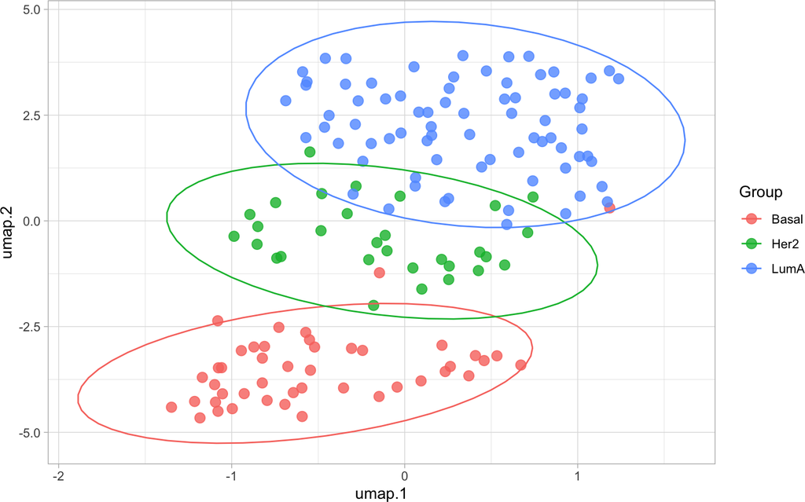

```r
ggplot(data = data.frame(Group = Y,
                         umap.1 = umap.mRNA$layout[,1],
                         umap.2 = umap.mRNA$layout[,2]),
       aes(colour=Group, x=umap.1, y=umap.2)) +
    geom_point(size=3, alpha=0.8) + theme_light() + stat_ellipse()
```

# 6 Discussion

- Unsupervised anlaysis is agnostic to the experiment groups - it is useful to initially view complex data.
- Clusters of samples may seem apparent to varying degrees, and potentially outliers that may raise the question of technical effects or misclassification.
- Compare your UMAP plot with your group. Try adding the set.seed() function to make UMAP plots exactly reproducible.

# 7 Hierarchical analysis

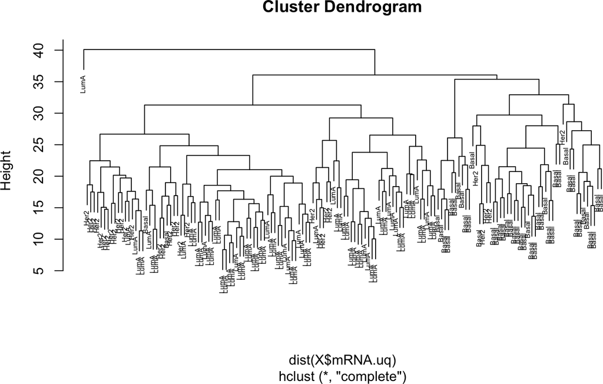

```r
hclusters <- hclust(dist(X$mRNA.uq))
plot(hclusters, cex=0.5, labels = Y)
```

```r
clusterCut <- cutree(hclusters, 7)
table(Y, clusterCut)
```

```
##        clusterCut
## Y        1  2  3  4  5  6  7
##   Basal 22 11 10  2  0  0  0
##   Her2   4  0  0 20  5  1  0
##   LumA   0  0  0 43 31  0  1
```

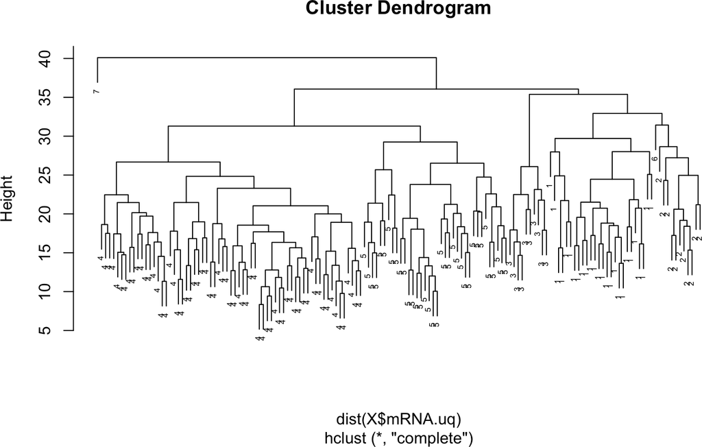

```r
plot(hclusters, cex=0.5, labels = clusterCut)
```

Now that we have a variable called *clusterCut*, we can combine it with our original group information, which is stored in the variable *Y*, and visualise the samples again on a PCA plot.

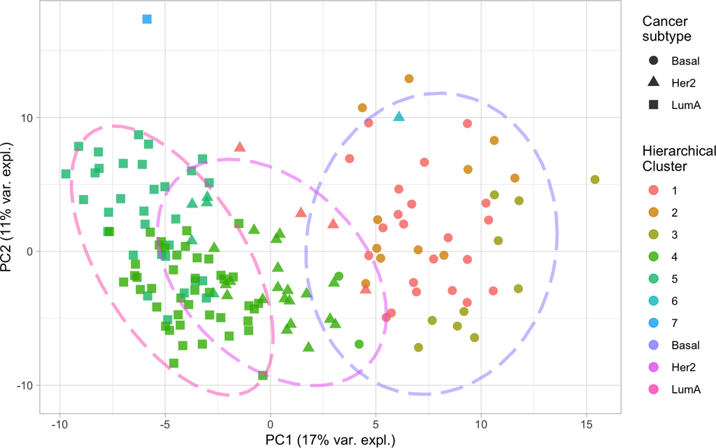

```r
# We can display a PCA plot, choosing symbols/colours to examine what's different
# between the original groupings and hierarchical groupings.
ggplot(data = data.frame(Group = Y, clusterCut, pca.mRNA$x),
       aes(colour=factor(clusterCut), shape=Y, x=PC1, y=PC2)) +
    geom_point(size=3, alpha=0.8) + theme_light() + labs(shape="Cancer\nsubtype", colour="Hierarchical\nCluster") +
  xlab(paste0("PC1 (", round(pca.mRNA$prop_expl_var$X[1]*100), "% var. expl.)")) +
  ylab(paste0("PC2 (", round(pca.mRNA$prop_expl_var$X[2]*100), "% var. expl.)")) +
  stat_ellipse(aes(colour=Y, group=Y), show.legend = FALSE,
               linetype = 5, lwd = 1.2, alpha = 0.5)
```

# 8 K-means

k-means is a different method to assign samples to groups. First, we choose the desired number of groups. The algorithm will randomly place a ‘centre’ for group somewhere on the plot, and then iterate between two steps: i) Samples are partitioned according to the cenres, and ii) the centre location is updated. The process continues until there is a convergence or a lack of further improvement/change in the grouping structure, or an iteration limit is reached.

```r
# add k-means subgrouping
set.seed(123)
km <- kmeans(X$mRNA.uq, centers=5, iter.max=1000)
table(Y, km$cluster)
```

```
##
## Y        1  2  3  4  5
##   Basal 21  0  3 21  0
##   Her2   0  2 25  2  1
##   LumA   0 21  6  0 48
```

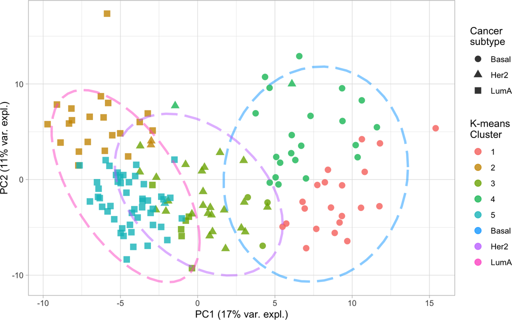

```r
ggplot(data = data.frame(Group = Y, kmeans = km$cluster, pca.mRNA$x),
       aes(colour=factor(kmeans), shape=Y, x=PC1, y=PC2)) +
    geom_point(size=3, alpha=0.8) + theme_light() + labs(shape="Cancer\nsubtype", colour="K-means\nCluster") +
  xlab(paste0("PC1 (", round(pca.mRNA$prop_expl_var$X[1]*100), "% var. expl.)")) +
  ylab(paste0("PC2 (", round(pca.mRNA$prop_expl_var$X[2]*100), "% var. expl.)"))  +
  stat_ellipse(aes(colour=Y, group=Y), show.legend = FALSE,
               linetype = 5, lwd = 1.2, alpha = 0.5)
```

# 9 Discussion

- Reasons explaining sample subclusters? Biological? Technical?
- Justifications to exclude an outlier point?

# 10 Multilevel (optional)

Experiments with a repeated design may benefit from using the “multilevel” feature, in most of the mixOmics methods. For instance, this might be useful in a pre/post treatment experiment, or time series, where you are most interested in is the effect of treatments, rather than the variations between all the individuals.

```r
data(vac18) # extract the vac18 data
str(vac18)
```

```
## List of 4
##  $ genes        : num [1:42, 1:1000] 5.5 5.4 4.74 4.87 4.9 ...
##   ..- attr(*, "dimnames")=List of 2
##   .. ..$ : chr [1:42] "X.115" "X.147" "X.163" "X.179" ...
##   .. ..$ : chr [1:1000] "ILMN_1677274" "ILMN_2357260" "ILMN_1815326" "ILMN_2347748" ...
##  $ stimulation  : Factor w/ 4 levels "LIPO5","GAG+",..: 1 1 1 1 1 1 1 1 1 1 ...
##  $ sample       : int [1:42] 8 7 9 11 10 1 12 2 4 5 ...
##  $ tab.prob.gene:'data.frame':   1000 obs. of  2 variables:
##   ..$ Probe: Factor w/ 24687 levels "ILMN_1343291",..: 3110 5729 20478 8071 13082 5042 10059 8594 3537 13971 ...
##   ..$ Gene : Factor w/ 34602 levels "7A5","A1BG","A1CF",..: 8036 30191 224 6002 28487 20518 24991 21735 18355 6853 ...
```

```r
# the first row is the sample IDs, the second row is the corresponding frequency of each ID
summary(as.factor(vac18$sample))
```

```
##  1  2  3  4  5  6  7  8  9 10 11 12
##  4  4  2  4  3  3  4  3  4  4  4  3
```

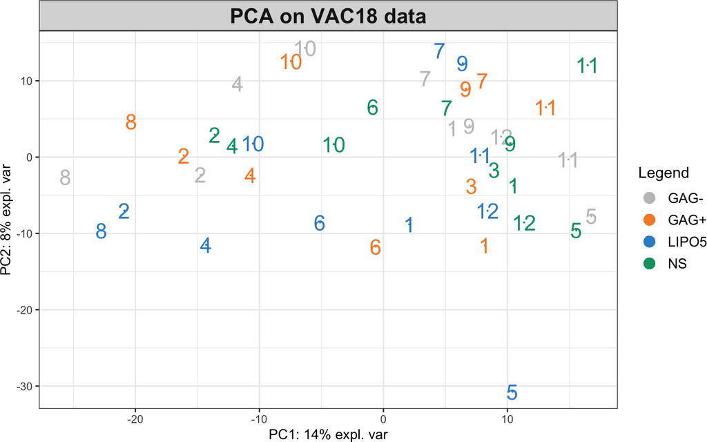

```r
# undergo PCA and plot samples without any multilevel decomposition
pca.result <- pca(vac18$genes, scale = TRUE)
plotIndiv(pca.result,
          ind.names = vac18$sample,
          group = vac18$stimulation,
          legend = TRUE, cex=6,
          title = 'PCA on VAC18 data')
```

```r
# undergo PCA and plot samples with multilevel decomposition
pca.result <- pca(vac18$genes, multilevel = vac18$sample, scale = TRUE)
```

```
## Splitting the variation for 1 level factor.
```

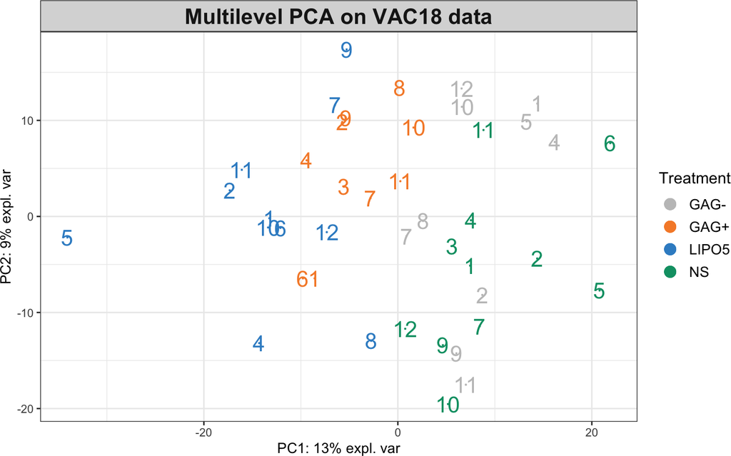

```r
plotIndiv(pca.result,
          ind.names = vac18$sample,
          group = vac18$stimulation,
          legend = TRUE, cex=6,
          legend.title = "Treatment",
          title = 'Multilevel PCA on VAC18 data')
```

# 11 Recap

- Data preparation
- PCA plots
- Component loadings
- UMAP
- ggplot
- Sub-clustering
- Multilevel